# Session 3: Clustering

Unsupervised grouping after PCA

O Rodriguez de Rivera Ortega, PhD

University of Exeter

# 1 Session overview

## 1.1 What is this session about?

This session introduces **clustering**, a family of methods used to find groups of observations based on their similarity.

In this session, we use the `palmerpenguins` dataset. We use continuous penguin measurements, such as bill length, bill depth, flipper length and body mass, to ask:

> Do penguins naturally group together based on their body measurements?

This is an **unsupervised** question. The clustering algorithm does not use the species labels when forming the groups. We can compare the clusters with species afterwards, but the species labels are not used to fit the clustering model.

## 1.2 Learning outcomes

By the end of this section, students should be able to:

- explain the difference between unsupervised clustering and supervised classification;
- prepare and scale continuous variables for clustering;
- apply k-means clustering to multivariate data;
- use elbow and silhouette plots to guide the choice of `k`;
- interpret cluster solutions by comparing them with known metadata;
- fit and interpret a simple hierarchical clustering tree;
- understand how clustering results can change depending on the variables and number of clusters used.

# 2 Clustering in context

## 2.1 Continuity from PCA

PCA reduces the number of dimensions in a multivariate dataset. It finds new axes that summarise the main gradients of variation.

Clustering asks a different question:

> Do observations naturally group together based on their multivariate similarity?

In this example, PCA can help us visualise the data in two dimensions, while clustering gives each penguin a group assignment.

## 2.2 Clustering versus discriminant analysis

| Clustering | Discriminant analysis |
| --- | --- |
| Unsupervised | Supervised |
| Does not use group labels | Uses known group labels |
| Finds groups from the data | Predicts predefined groups |
| Useful for exploration | Useful for classification |
| Groups may not match known labels | Groups are defined before modelling |

Clustering asks:

> Are there natural groups in the data?

Discriminant analysis asks:

> Given known groups, can we predict group membership?

# 3 Setup

## 3.1 Packages

```r
install.packages(c(
  "tidyverse",
  "palmerpenguins",
  "cluster",
  "patchwork"
))
```

```r
library(tidyverse)
library(palmerpenguins)
library(cluster)
library(patchwork)

theme_set(theme_minimal(base_size = 12))
```

# 4 Prepare the data

## 4.1 Clean the penguin data

```r
penguins_clean <- palmerpenguins::penguins %>%
  tidyr::drop_na(
    species,
    island,
    sex,
    bill_length_mm,
    bill_depth_mm,
    flipper_length_mm,
    body_mass_g
  ) %>%
  dplyr::mutate(
    species = factor(species),
    island = factor(island),
    sex = factor(sex)
  )

dplyr::glimpse(penguins_clean)
```

```
## Rows: 333
## Columns: 8
## $ species           <fct> Adelie, Adelie, Adelie, Adelie, Adelie, Adelie, Adel…
## $ island            <fct> Torgersen, Torgersen, Torgersen, Torgersen, Torgerse…
## $ bill_length_mm    <dbl> 39.1, 39.5, 40.3, 36.7, 39.3, 38.9, 39.2, 41.1, 38.6…
## $ bill_depth_mm     <dbl> 18.7, 17.4, 18.0, 19.3, 20.6, 17.8, 19.6, 17.6, 21.2…
## $ flipper_length_mm <int> 181, 186, 195, 193, 190, 181, 195, 182, 191, 198, 18…
## $ body_mass_g       <int> 3750, 3800, 3250, 3450, 3650, 3625, 4675, 3200, 3800…
## $ sex               <fct> male, female, female, female, male, female, male, fe…
## $ year              <int> 2007, 2007, 2007, 2007, 2007, 2007, 2007, 2007, 2007…
```

## 4.2 Select continuous traits

For clustering, we use continuous body measurements.

```r
penguin_traits <- penguins_clean %>%
  dplyr::select(
    bill_length_mm,
    bill_depth_mm,
    flipper_length_mm,
    body_mass_g
  )

dplyr::glimpse(penguin_traits)
```

```
## Rows: 333
## Columns: 4
## $ bill_length_mm    <dbl> 39.1, 39.5, 40.3, 36.7, 39.3, 38.9, 39.2, 41.1, 38.6…
## $ bill_depth_mm     <dbl> 18.7, 17.4, 18.0, 19.3, 20.6, 17.8, 19.6, 17.6, 21.2…
## $ flipper_length_mm <int> 181, 186, 195, 193, 190, 181, 195, 182, 191, 198, 18…
## $ body_mass_g       <int> 3750, 3800, 3250, 3450, 3650, 3625, 4675, 3200, 3800…
```

## 4.3 Scale the traits

Scaling is important because the variables are measured in different units and have different ranges.

For example, body mass is measured in grams, while bill length is measured in millimetres. Without scaling, variables with larger numerical ranges could dominate the clustering.

```r
traits_scaled <- penguin_traits %>%
  scale() %>%
  as.data.frame()

head(traits_scaled)
```

```
##   bill_length_mm bill_depth_mm flipper_length_mm body_mass_g
## 1     -0.8946955     0.7795590        -1.4246077  -0.5676206
## 2     -0.8215515     0.1194043        -1.0678666  -0.5055254
## 3     -0.6752636     0.4240910        -0.4257325  -1.1885721
## 4     -1.3335592     1.0842457        -0.5684290  -0.9401915
## 5     -0.8581235     1.7444004        -0.7824736  -0.6918109
## 6     -0.9312674     0.3225288        -1.4246077  -0.7228585
```

After scaling, each variable has approximately mean 0 and standard deviation 1.

# 5 Exploratory visualisation

## 5.1 Pairwise relationships

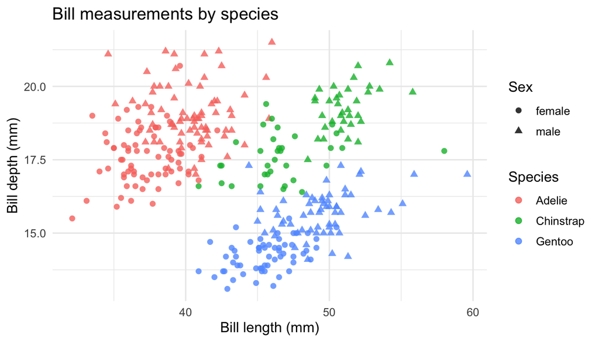

```r
ggplot(
  penguins_clean,
  aes(
    x = bill_length_mm,
    y = bill_depth_mm,
    colour = species,
    shape = sex
  )
) +
  geom_point(alpha = 0.8, size = 2) +
  labs(
    title = "Bill measurements by species",
    x = "Bill length (mm)",
    y = "Bill depth (mm)",
    colour = "Species",
    shape = "Sex"
  )
```

The species labels are shown here only for interpretation. They will not be used when fitting the clusters.

# 6 K-means clustering

## 6.1 What is k-means?

K-means clustering divides observations into `k` groups.

The algorithm tries to create clusters where observations are similar to others in the same cluster and different from observations in other clusters.

The user must choose the number of clusters, `k`, before fitting the model.

K-means works best when clusters are roughly:

- compact;
- separated;
- similar in size;
- based on continuous variables.

## 6.2 Fit k-means with three clusters

We start with `k = 3` because we know there are three penguin species. In a real unsupervised analysis, we may not know the correct number of groups.

```r
set.seed(123)

km3 <- kmeans(
  traits_scaled,
  centers = 3,
  nstart = 25
)

km3
```

```
## K-means clustering with 3 clusters of sizes 85, 129, 119
##
## Cluster means:
##   bill_length_mm bill_depth_mm flipper_length_mm body_mass_g
## 1      0.6710153     0.8040534        -0.2889118  -0.3835267
## 2     -1.0452359     0.4858944        -0.8803701  -0.7616078
## 3      0.6537742    -1.1010497         1.1607163   1.0995561
##
## Clustering vector:
##   [1] 2 2 2 2 2 2 2 2 2 2 2 2 1 2 1 2 2 2 2 2 2 2 2 2 2 2 2 2 2 2 2 2 2 2 2 2 2
##  [38] 2 1 2 2 2 2 1 2 2 2 1 2 2 2 2 2 2 2 1 2 2 2 2 2 2 2 1 2 2 2 1 2 1 2 2 2 1
##  [75] 2 1 2 2 2 2 2 2 2 2 2 1 2 2 2 1 2 2 2 1 2 1 2 2 2 2 2 2 2 1 2 1 2 1 2 1 2
## [112] 2 2 2 2 2 2 2 2 2 2 2 2 1 2 1 2 2 2 2 2 2 2 2 2 2 2 2 2 2 2 2 2 2 2 1 3 3
## [149] 3 3 3 3 3 3 3 3 3 3 3 3 3 3 3 3 3 3 3 3 3 3 3 3 3 3 3 3 3 3 3 3 3 3 3 3 3
## [186] 3 3 3 3 3 3 3 3 3 3 3 3 3 3 3 3 3 3 3 3 3 3 3 3 3 3 3 3 3 3 3 3 3 3 3 3 3
## [223] 3 3 3 3 3 3 3 3 3 3 3 3 3 3 3 3 3 3 3 3 3 3 3 3 3 3 3 3 3 3 3 3 3 3 3 3 3
## [260] 3 3 3 3 3 3 1 1 1 1 1 1 1 1 1 1 1 1 1 1 1 1 1 1 1 1 2 1 2 1 1 1 1 1 1 1 2
## [297] 1 2 1 1 1 1 1 1 1 1 1 1 1 1 1 1 1 1 1 1 1 1 1 2 1 1 1 1 1 1 1 1 1 1 1 1 1
##
## Within cluster sum of squares by cluster:
## [1] 109.4813 120.7030 139.4684
##  (between_SS / total_SS =  72.2 %)
##
## Available components:
##
## [1] "cluster"      "centers"      "totss"        "withinss"     "tot.withinss"
## [6] "betweenss"    "size"         "iter"         "ifault"
```

The argument `nstart = 25` runs the algorithm several times with different starting points and keeps the best solution. This is useful because k-means can give different results depending on the initial cluster centres.

# 7 Visualise clusters in PCA space

## 7.1 PCA for plotting

K-means was fitted using the scaled continuous traits. To visualise the clusters, we project the data into two PCA axes.

```r
pca_fit <- prcomp(
  penguin_traits,
  center = TRUE,
  scale. = TRUE
)

plot_data <- as_tibble(pca_fit$x[, 1:2]) %>%
  dplyr::bind_cols(
    penguins_clean %>%
      dplyr::select(species, island, sex)
  ) %>%
  dplyr::mutate(
    cluster = factor(km3$cluster)
  )

head(plot_data)
```

```
## # A tibble: 6 × 6
##     PC1     PC2 species island    sex    cluster
##   <dbl>   <dbl> <fct>   <fct>     <fct>  <fct>
## 1 -1.85 -0.0320 Adelie  Torgersen male   2
## 2 -1.31  0.443  Adelie  Torgersen female 2
## 3 -1.37  0.161  Adelie  Torgersen female 2
## 4 -1.88  0.0123 Adelie  Torgersen female 2
## 5 -1.92 -0.816  Adelie  Torgersen male   2
## 6 -1.77  0.366  Adelie  Torgersen female 2
```

## 7.2 Plot k-means clusters

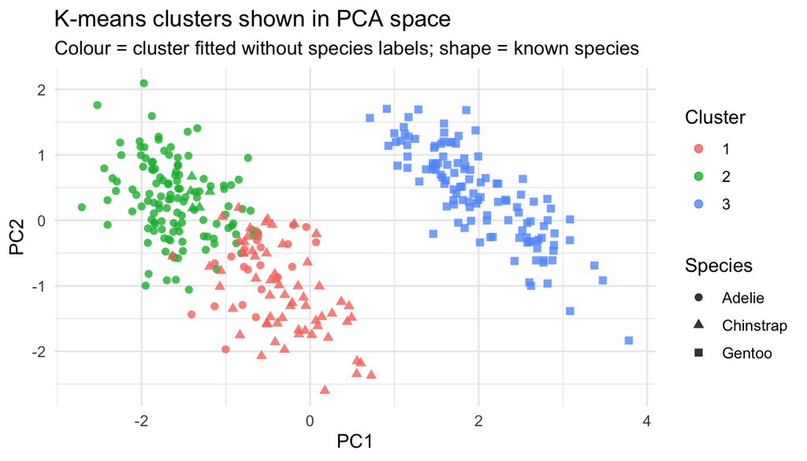

```r
ggplot(
  plot_data,
  aes(
    x = PC1,
    y = PC2,
    colour = cluster,
    shape = species
  )
) +
  geom_point(alpha = 0.8, size = 2) +
  labs(
    title = "K-means clusters shown in PCA space",
    subtitle = "Colour = cluster fitted without species labels; shape = known species",
    x = "PC1",
    y = "PC2",
    colour = "Cluster",
    shape = "Species"
  )
```

## 7.3 How to interpret this plot

The colours show the clusters found by k-means.

The shapes show the known species labels. These labels were not used when fitting the clusters.

If the colours and shapes match closely, then the body measurements naturally group penguins in a way that is similar to species.

If the colours and shapes do not match, this means that the clustering is capturing a different pattern in the data.

# 8 Compare clusters with known species

## 8.1 Cluster-species table

```r
table(
  cluster = plot_data$cluster,
  species = plot_data$species
)
```

```
##        species
## cluster Adelie Chinstrap Gentoo
##       1     22        63      0
##       2    124         5      0
##       3      0         0    119
```

This table is for interpretation only. The species label was not used to fit the clusters.

A good question to ask is:

> Do the clusters correspond mainly to species, or do they mix species together?

Clustering does not know what the correct biological groups are. It only groups observations based on the variables supplied to the algorithm.

# 9 Choosing the number of clusters

## 9.1 Why does `k` matter?

K-means requires the number of clusters to be chosen in advance.

Different values of `k` can lead to different interpretations.

There is rarely one objectively correct value. We usually combine statistical summaries with scientific interpretation.

# 10 Elbow method

## 10.1 Calculate within-cluster sum of squares

The elbow method looks at how the total within-cluster sum of squares changes as `k` increases.

As `k` increases, clusters become smaller and the within-cluster variation decreases. We look for a point where the improvement starts to level off.

```r
set.seed(123)

wss <- purrr::map_dbl(1:8, function(k) {
  kmeans(
    traits_scaled,
    centers = k,
    nstart = 25
  )$tot.withinss
})

elbow_data <- tibble::tibble(
  k = 1:8,
  total_within_ss = wss
)

elbow_data
```

```
## # A tibble: 8 × 2
##       k total_within_ss
##   <int>           <dbl>
## 1     1           1328.
## 2     2            551.
## 3     3            370.
## 4     4            293.
## 5     5            228.
## 6     6            200.
## 7     7            182.
## 8     8            166.
```

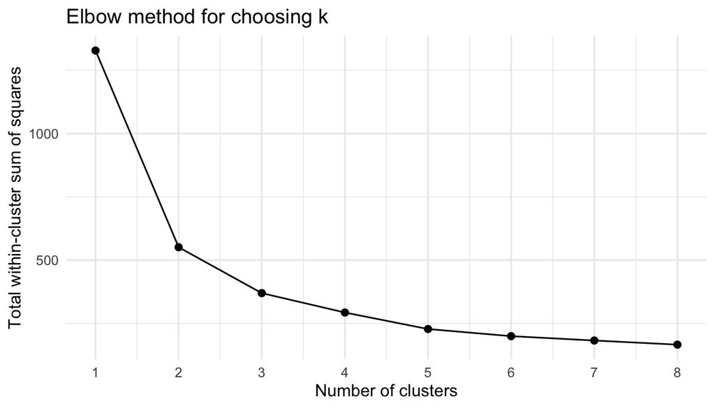

```r
ggplot(elbow_data, aes(x = k, y = total_within_ss)) +
  geom_line() +
  geom_point(size = 2) +
  scale_x_continuous(breaks = 1:8) +
  labs(
    title = "Elbow method for choosing k",
    x = "Number of clusters",
    y = "Total within-cluster sum of squares"
  )
```

## 10.2 Interpreting the elbow plot

The total within-cluster sum of squares always decreases as `k` increases.

The aim is not to choose the largest `k`. Instead, we look for an elbow: a value of `k` after which the improvement becomes smaller.

The elbow method is useful, but it can be subjective.

# 11 Silhouette method

## 11.1 Calculate mean silhouette width

The silhouette method measures how well each observation fits within its assigned cluster compared with other clusters.

Values close to 1 suggest that an observation is well matched to its cluster. Values near 0 suggest it lies between clusters. Negative values suggest it may be assigned to the wrong cluster.

```r
set.seed(123)

silhouette_data <- purrr::map_dfr(2:8, function(k) {
  km <- kmeans(
    traits_scaled,
    centers = k,
    nstart = 25
  )

  sil <- cluster::silhouette(
    km$cluster,
    dist(traits_scaled)
  )

  tibble::tibble(
    k = k,
    mean_silhouette = mean(sil[, "sil_width"])
  )
})

silhouette_data
```

```
## # A tibble: 7 × 2
##       k mean_silhouette
##   <int>           <dbl>
## 1     2           0.531
## 2     3           0.446
## 3     4           0.398
## 4     5           0.374
## 5     6           0.364
## 6     7           0.332
## 7     8           0.301
```

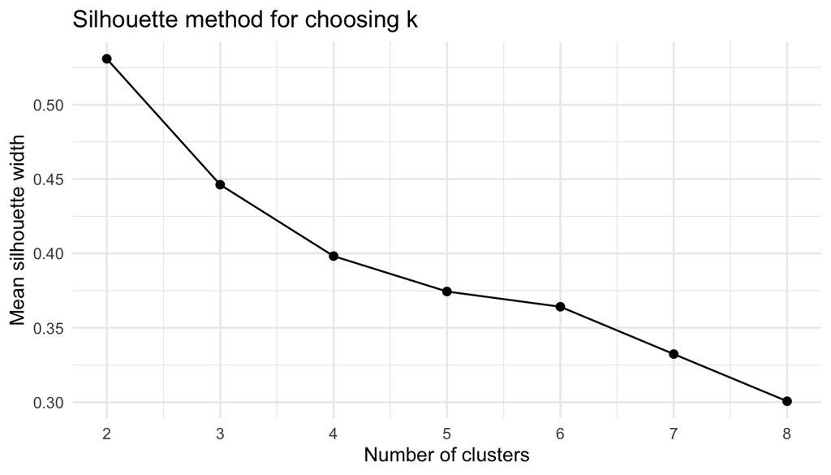

```r
ggplot(
  silhouette_data,
  aes(
    x = k,
    y = mean_silhouette
  )
) +
  geom_line() +
  geom_point(size = 2) +
  scale_x_continuous(breaks = 2:8) +
  labs(
    title = "Silhouette method for choosing k",
    x = "Number of clusters",
    y = "Mean silhouette width"
  )
```

## 11.2 Interpreting silhouette width

A larger mean silhouette width suggests better-separated clusters.

However, the best statistical value is not always the best scientific answer. The choice of `k` should also make sense in relation to the research question.

# 12 Cluster interpretation

## 12.1 Add cluster labels to the data

```r
penguins_clustered <- penguins_clean %>%
  dplyr::mutate(
    cluster = factor(km3$cluster)
  )

head(penguins_clustered)
```

```
## # A tibble: 6 × 9
##   species island    bill_length_mm bill_depth_mm flipper_length_mm body_mass_g
##   <fct>   <fct>              <dbl>         <dbl>             <int>       <int>
## 1 Adelie  Torgersen           39.1          18.7               181        3750
## 2 Adelie  Torgersen           39.5          17.4               186        3800
## 3 Adelie  Torgersen           40.3          18                 195        3250
## 4 Adelie  Torgersen           36.7          19.3               193        3450
## 5 Adelie  Torgersen           39.3          20.6               190        3650
## 6 Adelie  Torgersen           38.9          17.8               181        3625
## # ℹ 3 more variables: sex <fct>, year <int>, cluster <fct>
```

## 12.2 Summarise traits by cluster

```r
penguins_clustered %>%
  dplyr::group_by(cluster) %>%
  dplyr::summarise(
    n = dplyr::n(),
    mean_bill_length = mean(bill_length_mm),
    mean_bill_depth = mean(bill_depth_mm),
    mean_flipper_length = mean(flipper_length_mm),
    mean_body_mass = mean(body_mass_g),
    .groups = "drop"
  )
```

```
## # A tibble: 3 × 6
##   cluster     n mean_bill_length mean_bill_depth mean_flipper_length
##   <fct>   <int>            <dbl>           <dbl>               <dbl>
## 1 1          85             47.7            18.7                197.
## 2 2         129             38.3            18.1                189.
## 3 3         119             47.6            15.0                217.
## # ℹ 1 more variable: mean_body_mass <dbl>
```

This helps describe the biological meaning of each cluster.

For example, one cluster may contain larger penguins with longer flippers and higher body mass, while another may contain smaller penguins with shorter flippers.

## 12.3 Plot body mass by cluster

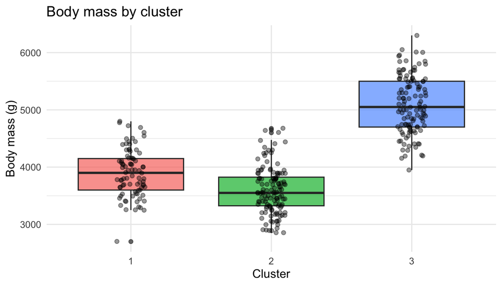

```r
ggplot(
  penguins_clustered,
  aes(
    x = cluster,
    y = body_mass_g,
    fill = cluster
  )
) +
  geom_boxplot(alpha = 0.7) +
  geom_jitter(width = 0.1, alpha = 0.4) +
  guides(fill = "none") +
  labs(
    title = "Body mass by cluster",
    x = "Cluster",
    y = "Body mass (g)"
  )
```

# 13 Hierarchical clustering

## 13.1 What is hierarchical clustering?

Hierarchical clustering builds a tree showing how observations are joined together based on similarity.

Unlike k-means, hierarchical clustering does not require us to choose the number of clusters before fitting the tree. Instead, we fit the tree first and then decide where to cut it.

## 13.2 Fit a hierarchical clustering tree

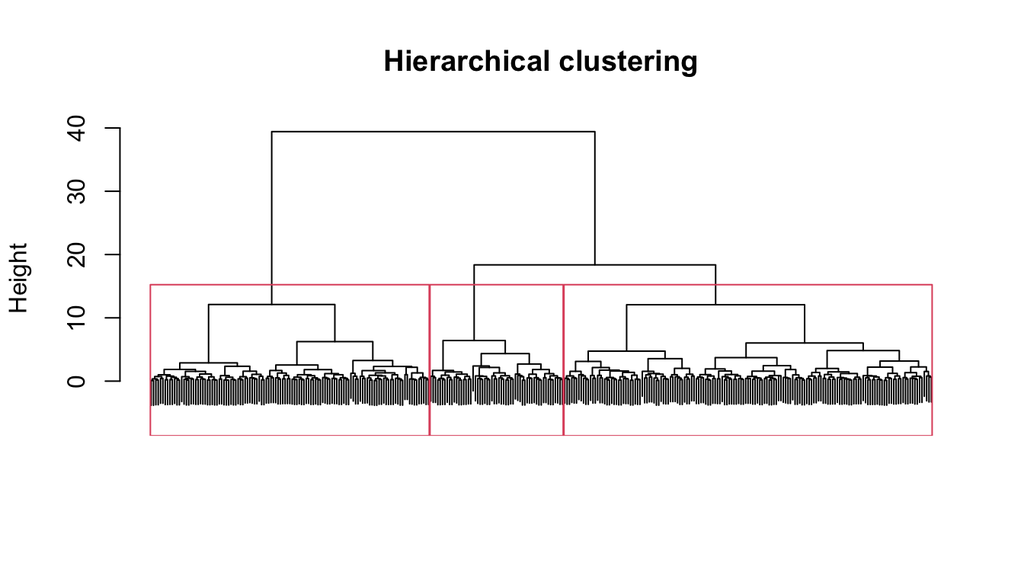

```r
trait_distance <- dist(
  traits_scaled,
  method = "euclidean"
)

hc <- hclust(
  trait_distance,
  method = "ward.D2"
)

plot(
  hc,
  labels = FALSE,
  main = "Hierarchical clustering",
  xlab = "",
  sub = ""
)

rect.hclust(hc, k = 3)
```

The tree shows how observations are joined together step by step.

The rectangles show one possible cut of the tree into three clusters.

## 13.3 Cut the tree into three groups

```r
hc_groups <- cutree(
  hc,
  k = 3
)

table(
  hierarchical_cluster = hc_groups,
  species = penguins_clean$species
)
```

```
##                     species
## hierarchical_cluster Adelie Chinstrap Gentoo
##                    1    146        11      0
##                    2      0         0    119
##                    3      0        57      0
```

K-means and hierarchical clustering may not give exactly the same grouping because they optimise different criteria.

K-means partitions observations into a fixed number of compact clusters. Hierarchical clustering builds a nested tree of similarity.

# 14 Practical exercise

## 14.1 Exercise: sensitivity to choices

1. Repeat k-means with `centers = 2`, `3` and `4`.
2. Compare the cluster tables with species.
3. Repeat the analysis using only bill traits.
4. Does the interpretation change?
5. Which cluster solution would you report, and why?

```r
set.seed(123)

km2 <- kmeans(traits_scaled, centers = 2, nstart = 25)
km3 <- kmeans(traits_scaled, centers = 3, nstart = 25)
km4 <- kmeans(traits_scaled, centers = 4, nstart = 25)

table(cluster = km2$cluster, species = penguins_clean$species)
table(cluster = km3$cluster, species = penguins_clean$species)
table(cluster = km4$cluster, species = penguins_clean$species)
```

# 15 Exercise solution

## 15.1 Repeat k-means with two, three and four clusters

```r
set.seed(123)

km2 <- kmeans(
  traits_scaled,
  centers = 2,
  nstart = 25
)

km3 <- kmeans(
  traits_scaled,
  centers = 3,
  nstart = 25
)

km4 <- kmeans(
  traits_scaled,
  centers = 4,
  nstart = 25
)
```

## 15.2 Compare cluster tables with species

```r
table(
  cluster = km2$cluster,
  species = penguins_clean$species
)
```

```
##        species
## cluster Adelie Chinstrap Gentoo
##       1      0         0    119
##       2    146        68      0
```

```r
table(
  cluster = km3$cluster,
  species = penguins_clean$species
)
```

```
##        species
## cluster Adelie Chinstrap Gentoo
##       1     22        63      0
##       2      0         0    119
##       3    124         5      0
```

```r
table(
  cluster = km4$cluster,
  species = penguins_clean$species
)
```

```
##        species
## cluster Adelie Chinstrap Gentoo
##       1    124         5      0
##       2      0         0     62
##       3     22        63      0
##       4      0         0     57
```

These tables help us see whether the clusters correspond to known species.

Remember that species labels were not used to fit the clusters. The comparison is only used after clustering to help interpret the groups.

## 15.3 Visualise the three solutions in PCA space

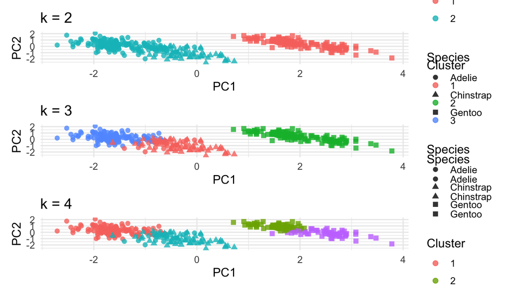

```r
plot_data_sensitivity <- as_tibble(pca_fit$x[, 1:2]) %>%
  dplyr::bind_cols(
    penguins_clean %>%
      dplyr::select(species)
  ) %>%
  dplyr::mutate(
    k2 = factor(km2$cluster),
    k3 = factor(km3$cluster),
    k4 = factor(km4$cluster)
  )

plot_k2 <- ggplot(
  plot_data_sensitivity,
  aes(x = PC1, y = PC2, colour = k2, shape = species)
) +
  geom_point(alpha = 0.8, size = 2) +
  labs(
    title = "k = 2",
    colour = "Cluster",
    shape = "Species"
  )

plot_k3 <- ggplot(
  plot_data_sensitivity,
  aes(x = PC1, y = PC2, colour = k3, shape = species)
) +
  geom_point(alpha = 0.8, size = 2) +
  labs(
    title = "k = 3",
    colour = "Cluster",
    shape = "Species"
  )

plot_k4 <- ggplot(
  plot_data_sensitivity,
  aes(x = PC1, y = PC2, colour = k4, shape = species)
) +
  geom_point(alpha = 0.8, size = 2) +
  labs(
    title = "k = 4",
    colour = "Cluster",
    shape = "Species"
  )

plot_k2 / plot_k3 / plot_k4
```

## 15.4 Repeat using only bill traits

Now we repeat the analysis using only bill length and bill depth.

```r
bill_traits <- penguins_clean %>%
  dplyr::select(
    bill_length_mm,
    bill_depth_mm
  )

bill_traits_scaled <- bill_traits %>%
  scale() %>%
  as.data.frame()

set.seed(123)

km_bill_3 <- kmeans(
  bill_traits_scaled,
  centers = 3,
  nstart = 25
)

table(
  cluster = km_bill_3$cluster,
  species = penguins_clean$species
)
```

```
##        species
## cluster Adelie Chinstrap Gentoo
##       1      0         9    112
##       2    142         5      1
##       3      4        54      6
```

## 15.5 Visualise bill-trait clusters

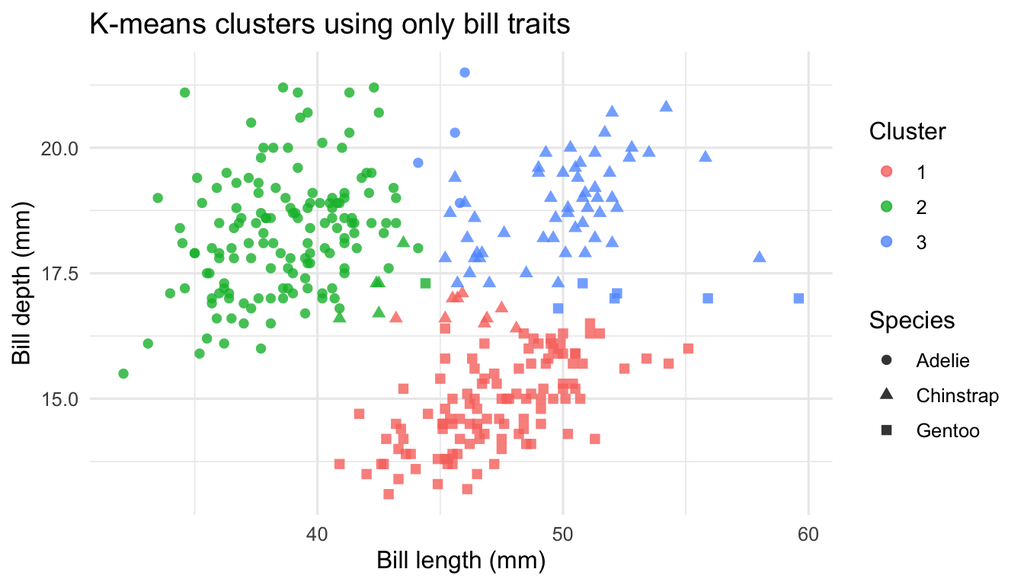

```r
bill_plot_data <- penguins_clean %>%
  dplyr::mutate(
    cluster = factor(km_bill_3$cluster)
  )

ggplot(
  bill_plot_data,
  aes(
    x = bill_length_mm,
    y = bill_depth_mm,
    colour = cluster,
    shape = species
  )
) +
  geom_point(alpha = 0.8, size = 2) +
  labs(
    title = "K-means clusters using only bill traits",
    x = "Bill length (mm)",
    y = "Bill depth (mm)",
    colour = "Cluster",
    shape = "Species"
  )
```

## 15.6 Does the interpretation change?

The interpretation may change because the clustering now uses only bill morphology.

When all traits are used, the clusters may reflect overall body size as well as bill shape. This means variables such as flipper length and body mass can strongly influence the grouping.

When only bill traits are used, the clusters focus more narrowly on differences in bill morphology.

Therefore, different variable choices can lead to different biological interpretations.

## 15.7 Which cluster solution would you report?

There is not always one correct answer.

A reasonable answer is:

- report the three-cluster solution using all traits if the aim is to compare clustering with the three known species;
- report the bill-trait solution if the scientific question is specifically about bill morphology;
- avoid reporting a solution only because it matches species labels, because clustering is unsupervised;
- use elbow and silhouette plots, cluster summaries and biological interpretation together.

For teaching, the `k = 3` solution is useful because students can compare unsupervised clusters with the three known species. However, it is important to emphasise that the species labels were not used to fit the clusters.

# 16 Summary

In this session, we used clustering to explore whether penguins form groups based on continuous body measurements.

Key points:

- clustering is unsupervised;
- k-means requires the number of clusters to be chosen in advance;
- scaling is important before clustering;
- elbow and silhouette plots help guide the choice of `k`;
- cluster labels should be interpreted using metadata and variable summaries;
- hierarchical clustering provides a tree-based view of similarity;
- clustering results depend on the variables included and the method used.

# 17 Transition to discriminant analysis

Clustering ignored the species label.

The next session asks a supervised question:

> If we know the groups, can we build axes that separate them as clearly as possible?

This leads naturally to discriminant analysis, where species labels are used directly to find axes that best separate predefined groups.